# Homework 2, Group 9: to the Client

Report developed for a homework activity during the class STAT 6210 - R Programming for Data Science (Auburn University, Fall 2020). The general idea is that the group works as a quantitative analysts for an investment bank, and we needed to present a Portfolio for our boss (Dr. Molinari, in this very real case) with a client’s options. This document was produced in RMarkDown, and finalized in October 02, 2020. One can find more about this assignment [here](https://github.com/AU-R-Programming/HW2-9/blob/master/ToTheClient.Rmd).

## Dear valued Client,

### Please find below our finalized report with your current options. Please contact us if you need anything else, we will be happy to assist you in this new journey!.

#### Best regards,

##### Ana Gabriela Itokazu, Jianfeng Zhang, and Takhellambam Bijoychandra Singh.

## Financial Report

The stocks considered for this report are listed in the [S&P 500](https://en.wikipedia.org/wiki/List_of_S%26P_500_companies) (Standard & Poor’s 500 Index), which incorporates the current 500 largest U.S. publicly traded companies. This was done not only based on the availability of the data, but also because this data base is a benchmark for financial analysis. For an optimized portfolio, we based our analysis in 5 randomly-sampled companies from the S&P 500, and simulated portfolios of different sizes (1, 2, and 3 companies), and with different options of weights for the said companies, in order to find the least risk.

The five companies that were selected are listed below, each followed by its label, that is used to identify the stock in the databases.

- Fortive Corp (FTV)
- Zimmer Biomet Holdings Inc. (ZBH)
- Oracle Corporation (ORCL)
- Citrix Systems, Inc. (CTXS)
- Xilinx, Inc. (XLNX)

For us to better evaluate your options, this analysis included a time span considering the behavior of the said companies stocks for last 3 years: from 2017-09-01 until 2020-09-01.

### Simulations

We analyzed the data for the Closing Prices for all five companies within the said time span, likewise:

| FTV | ZBH | ORCL | CTXS | XLNX |
| --- | --- | --- | --- | --- |
| -0.0001536406 | -0.0007872299 | 0.006124082 | -0.019485469 | -0.022427581 |
| -0.0055306963 | 0.0121673584 | 0.001570744 | -0.008312768 | -0.006200604 |
| 0.0129769344 | 0.0003459396 | 0.014114919 | -0.012966562 | 0.003275604 |
| 0.0138783438 | 0.0002593499 | -0.002899633 | -0.002919347 | -0.010105752 |
| 0.0156437117 | 0.0008643561 | 0.017642496 | 0.015171680 | 0.016491331 |
| 0.0051837384 | 0.0054403885 | 0.005334311 | 0.002884124 | 0.004326313 |

To do that, we assembled combinations of stocks to generate all the possible portfolios of sizes 1, 2, and 3 stocks; yielding 25 different Portfolios to consider. We considered both Expected Returns and Risk for each of the stock, and optimized the options by calculating different weights for each stock on the Portfolios of sizes bigger than 1, so the total investment is used properly.

Graphically, this is shown in the plot below. Your portfolio of choice is represented by the green dot, with the lowest risk. All other considered portfolios are represented by blue dots, with the one with the highest return in red, just for curiosity. The total risk of your best portfolio is 176.4 millions and the daily expected return is 719.22. The weight for each stock is 0.21 for *Fortive Corp. Stock*, 0.23 for *Zimmer Biomet Holdings Inc. Stock*, and 0.57 for *Citrix Systems Inc. Stock*. In case you are interested, please refer to the table with the full results in the Appendix.

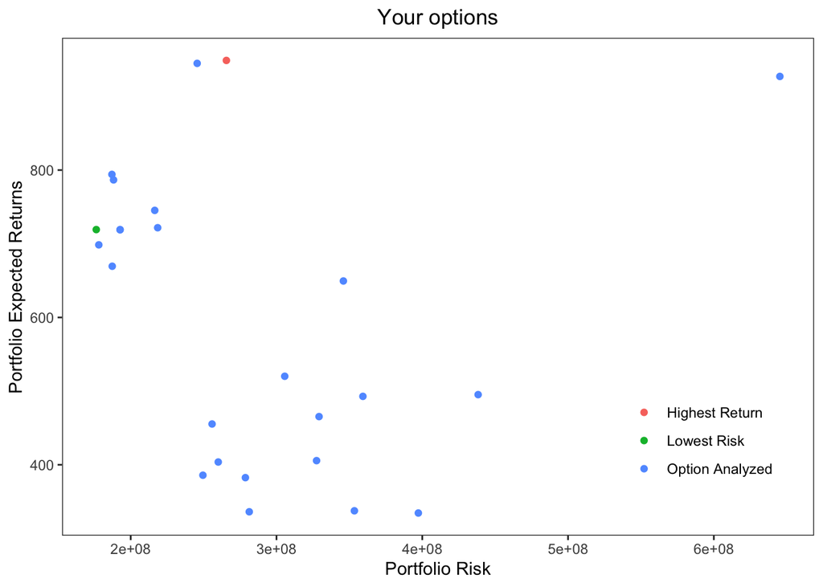

Therefore, we recommend that you invest in the portfolio 17. This includes the companies *Fortive Corp. Stock*, *Zimmer Biomet Holdings Inc. Stock*, and *Citrix Systems Inc. Stock*, and it considers the minimum risk possible.

In case of any doubt please let us know so we can better assist you.!

### Appendix

Table with all portfolio options, representing the weights for each company stock and respective Expected Return and Risks. The portfolio option with the lowest risk is highlighted in green, and the option with the highest return, in grey.

| FTV | ZBH | ORCL | CTXS | XLNX | Expected Return | Risk | Status |
| --- | --- | --- | --- | --- | --- | --- | --- |
| 1.0000000 | 0.0000000 | 0.0000000 | 0.0000000 | 0.0000000 | 334.5191 | 397301521 | Option Analyzed |
| 0.0000000 | 1.0000000 | 0.0000000 | 0.0000000 | 0.0000000 | 495.2125 | 438311512 | Option Analyzed |
| 0.0000000 | 0.0000000 | 1.0000000 | 0.0000000 | 0.0000000 | 337.5462 | 353439412 | Option Analyzed |
| 0.0000000 | 0.0000000 | 0.0000000 | 1.0000000 | 0.0000000 | 948.8037 | 265630619 | Highest Return |
| 0.0000000 | 0.0000000 | 0.0000000 | 0.0000000 | 1.0000000 | 927.0872 | 645290397 | Option Analyzed |
| 0.5575073 | 0.4424927 | 0.0000000 | 0.0000000 | 0.0000000 | 405.6248 | 327486485 | Option Analyzed |
| 0.4408883 | 0.0000000 | 0.5591117 | 0.0000000 | 0.0000000 | 336.2116 | 281321516 | Option Analyzed |
| 0.3738190 | 0.0000000 | 0.0000000 | 0.6261810 | 0.0000000 | 719.1725 | 192720352 | Option Analyzed |
| 0.7327911 | 0.0000000 | 0.0000000 | 0.0000000 | 0.2672089 | 492.8586 | 359270523 | Option Analyzed |
| 0.0000000 | 0.4198889 | 0.5801111 | 0.0000000 | 0.0000000 | 403.7486 | 260047090 | Option Analyzed |
| 0.0000000 | 0.3574571 | 0.0000000 | 0.6425429 | 0.0000000 | 786.6644 | 188234996 | Option Analyzed |
| 0.0000000 | 0.6428366 | 0.0000000 | 0.0000000 | 0.3571634 | 649.4624 | 345886268 | Option Analyzed |
| 0.0000000 | 0.0000000 | 0.3714568 | 0.6285432 | 0.0000000 | 721.7480 | 218502999 | Option Analyzed |
| 0.0000000 | 0.0000000 | 0.7831179 | 0.0000000 | 0.2168821 | 465.4071 | 329195026 | Option Analyzed |
| 0.0000000 | 0.0000000 | 0.0000000 | 0.8170485 | 0.1829515 | 944.8307 | 245590001 | Option Analyzed |
| 0.2133114 | 0.3103244 | 0.4763642 | 0.0000000 | 0.0000000 | 385.8282 | 249524380 | Option Analyzed |
| 0.2071084 | 0.2256615 | 0.0000000 | 0.5672300 | 0.0000000 | 719.2221 | 176376238 | Lowest Risk |
| 0.3989490 | 0.3948847 | 0.0000000 | 0.0000000 | 0.2061663 | 520.1420 | 305654926 | Option Analyzed |
| 0.3008701 | 0.0000000 | 0.1546276 | 0.5445023 | 0.0000000 | 669.4666 | 187330447 | Option Analyzed |
| 0.4035096 | 0.0000000 | 0.5180945 | 0.0000000 | 0.0783959 | 382.5423 | 278672134 | Option Analyzed |
| 0.3742542 | 0.0000000 | 0.0000000 | 0.6265183 | -0.0007726 | 718.9219 | 192720093 | Option Analyzed |
| 0.0000000 | 0.2906628 | 0.1937872 | 0.5155500 | 0.0000000 | 698.5078 | 178110854 | Option Analyzed |
| 0.0000000 | 0.3910622 | 0.5136816 | 0.0000000 | 0.0952562 | 455.3610 | 255810454 | Option Analyzed |
| 0.0000000 | 0.3387655 | 0.0000000 | 0.6140531 | 0.0471814 | 794.1181 | 187113772 | Option Analyzed |
| 0.0000000 | 0.0000000 | 0.3306288 | 0.6037281 | 0.0656431 | 745.2788 | 216492360 | Option Analyzed |